# CFRM 502, Winter 2020

# Instructor: Bahman Angoshtari

# Lecture 6

**Chapter 21:** local polynomial regression, optimal bandwidth, spline regression

**Chapter 12:** weak and strict stationary time series, autocorrelation functions (ACF), Ljung-Box test

$\newcommand{\eps}{\varepsilon}$ $\newcommand{\Var}{\operatorname{Var}}$ $\newcommand\Cov{\operatorname{Cov}}$ $\newcommand{\sig}{\sigma}$ $\newcommand{\al}{\alpha}$ $\newcommand{\Xb}{\bar{X}}$ $\newcommand{\Yb}{\bar{Y}}$ $\newcommand\Eb{\mathbb{E}}$ $\newcommand\Pb{\mathbb{P}}$ $\newcommand\Qb{\mathbb{Q}}$ $\newcommand\Rb{\mathbb{R}}$ $\newcommand\Zb{\mathbb{Z}}$ $\newcommand\Nb{\mathbb{N}}$ $\newcommand\Av{\textbf{A}}$ $\newcommand\Fv{\textbf{F}}$ $\newcommand\Gv{\textbf{G}}$ $\newcommand\Hv{\textbf{H}}$ $\newcommand\Kv{\textbf{K}}$ $\newcommand\Iv{\textbf{I}}$ $\newcommand\Pv{\textbf{P}}$ $\newcommand\Sv{\textbf{S}}$ $\newcommand\Xv{\textbf{X}}$ $\newcommand\Yv{\textbf{Y}}$ $\newcommand\Zv{\textbf{Z}}$ $\newcommand\av{\mathbf{a}}$ $\newcommand\xv{\mathbf{x}}$ $\newcommand\yv{\mathbf{y}}$ $\newcommand\zv{\mathbf{z}}$ $\newcommand\Cv{\mathbf{C}}$ $\newcommand\mv{\mathbf{m}}$ $\newcommand\nv{\mathbf{n}}$ $\newcommand\pv{\mathbf{p}}$ $\newcommand\sv{\mathbf{s}}$ $\newcommand\wv{\mathbf{w}}$ $\newcommand\Wv{\textbf{W}}$ $\newcommand\betav{{\boldsymbol\beta}}$ $\newcommand\etav{{\boldsymbol\eta}}$ $\newcommand\epsv{{\boldsymbol\varepsilon}}$ $\newcommand\delv{{\boldsymbol\delta}}$ $\newcommand\Lamv{{\boldsymbol\Lambda}}$ $\newcommand\lamv{{\boldsymbol\lambda}}$ $\newcommand\muv{{\boldsymbol\mu}}$ $\newcommand\piv{{\boldsymbol\pi}}$ $\newcommand\Pbh{\widehat{\Pb}}$ $\newcommand\Ebh{\widehat{\Eb}}$ $\newcommand\Qh{\widehat{Q}}$ $\newcommand\Ih{\widehat{I}}$ $\newcommand\pih{\widehat{\pi}}$ $\newcommand\Pih{\widehat{\Pi}}$ $\newcommand\Wh{\widehat{W}}$ $\newcommand\Fh{\widehat{F}}$ $\newcommand\Yh{\widehat{Y}}$ $\newcommand\Yvh{\widehat{\Yv}}$ $\newcommand\Ah{\widehat{\Ac}}$ $\newcommand\uh{\widehat{u}}$ $\newcommand\vh{\widehat{v}}$ $\newcommand\fh{\widehat{f}}$ $\newcommand\hh{\widehat{h}}$ $\newcommand\Bh{\widehat{B}}$ $\newcommand\rhoh{\widehat{\rho}}$ $\newcommand\nuh{\widehat{\nu}}$ $\newcommand\varphih{\widehat{\varphi}}$ $\newcommand\alh{\widehat{\al}}$ $\newcommand\thetah{\widehat{\theta}}$ $\newcommand\betah{\widehat{\beta}}$ $\newcommand\betavh{\widehat{\boldsymbol\beta}}$ $\newcommand\kaph{\widehat{\kappa}}$ $\newcommand\sigh{\widehat{\sigma}}$ $\newcommand\epsh{\widehat{\eps}}$ $\newcommand\epsvh{\widehat{\epsv}}$ $\newcommand\epst{\widetilde{\eps}}$ $\newcommand\muh{\widehat{\mu}}$ $\newcommand\dd{\mathrm{d}}$ $\newcommand\ee{\mathrm{e}}$

# 0. Overview of the lecture

- In the previous lecture, we studied various parametric non-linear models of the type

\begin{align*} Y_n = f(\Xv_n;\betav) + \eps_n;\quad n\in\{1,\dots,N\} \end{align*}

- Q: How should we choose the regression function $f(\Xv;\betav)$?

  A: Using context-specific knowledge and/or experience, trial and error...
- A more systematic way is to *"let the data decides"*. This is the approach taken by **"non-parametric regression models"**
- In the first part of the lecture, we study two common non-parametric models. Namely, **Local polynomial regression** and **Splines**
- We start the study of time-series models in the second part of the lecture.

# 1. Local polynomial regression

- Given a sample ${(X_n, Y_n)}_{n=1}^N$, we want to estimate a function $\mu$ such that

\begin{align*} Y_n = \mu(X_n) + \eps_n \end{align*}

- Here, $\{\eps_n\}$ is an i.i.d white noise
- Note the difference between the model and that of a parametric non-linear regression: there is no parameter $\beta_i$!
- **Idea:** Break the range $\displaystyle[\min_n X_n,\; \max_n X_n]$ into a grid

  $x_1=X_{min} < x_2 <\dots < x_m = X_{max}$

  Specify $\mu()$ by choosing the values $\mu_k=\mu(x_k)$ for $k\in\{1,\dots,m\}$. Estimate $\mu(x_k)$ from the observations for which $X_n$ is nearer to $x_k$
- How to estimate $\mu(x_x)$ for observation with $X_n$ near $x_k$?
- Fit a polynomial regression, but, weigh the observation according to how near their $X$ value is to $x_k$
- or estimating $\mu(x_k)$, use the following **kernel-weighted least squares**

\begin{align*} \betavh(k) = \underset{\betav}{\arg\min} \sum_{n=1}^N \Big[Y_n - \beta_0 - \beta_1(X_n-x_k) - \dots - \beta_p(X_n-x_k)^p\Big]\,K\left(\frac{X_n-x_k}{h}\right) \end{align*}

- Here, $K(x)$ is a kernel function, that is: $K(x)\ge0$, $\displaystyle\int_{\Rb}K(x)\dd x =1$, and $k(x)$ is symmetric
- Note that an estimate of $\mu(x_k)$ is $\muh(x_k) = \beta_0(k)$
- By estimating $\beta_0(k)$ for all $k$ (i.e. all the points on the grid), we obtain an estimate of $\mu$
- Let us illustrate the idea by using simulated data

```r
# Setting parameters of the Jupyter notebook
sc = .75
options(repr.plot.width=16*sc,
        repr.plot.height=7*sc,
        repr.plot.pointsize = 13, # Text height in pt
        repr.plot.bg        = 'white',
        repr.plot.antialias = 'gray',
        #nice medium-res DPI
        repr.plot.res       = 300,
        #jpeg quality bumped from default
        repr.plot.quality   = 90,
        #vector font family
        repr.plot.family    = 'serif') # Vector font family. 'sans', 'serif', 'mono' or a specific one
```

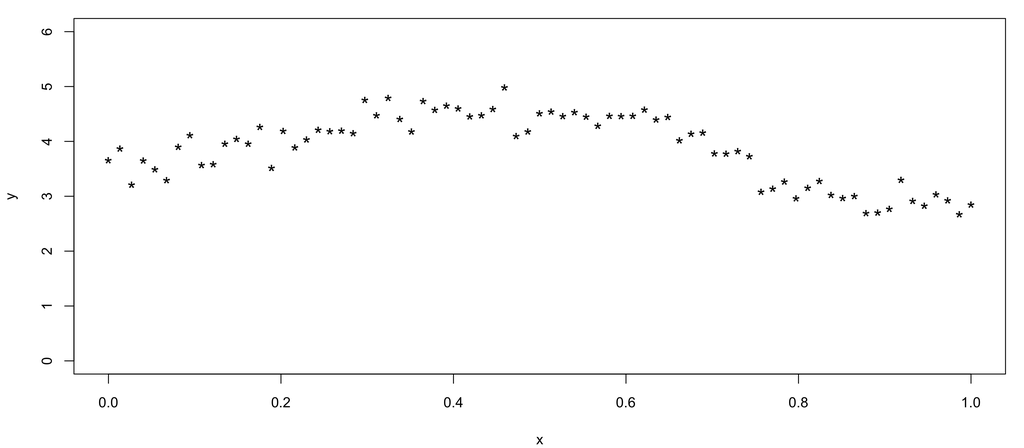

```r
set.seed("9988")
x = seq(0,1,length=75)
true = .1*x+ sin(5* x^1.5) + 3.6
y = true + rnorm(75,sd=.2)
par(mar=c(4,4,1,1))
plot(x,y,ylim=c(0,6),cex=1.5,pch="*")
```

- To find the estimate for $\mu(0.2)$, we first fit a local linear regression model (so, p=1)

  $\underset{\betav}{\min} \sum_{n=1}^N \Big[Y_n - \beta_0 - \beta_1(X_n-0.2) \Big]\,K\left(\frac{X_n-0.2}{h}\right)$

  To estimate the weighted LS, we can use the argument `weights` of the `lm()` function

```r
h=0.05  # arbitrarily choosing the bandwidth
x1 = 0.2
scale=.25;w1 = scale*dnorm(x,mean=x1,sd=h)
fit1 = lm(y~I(x-x1),weights=w1) # finding the local linear regression at x=0.2
```

- Then, we estimate $\mu(0.2)\approx$ $\betah_0 =4.02$

```r
coef(fit1)
```

**(Intercept)**

4.02046166743833

**I(x - x1)**

2.73370695558918

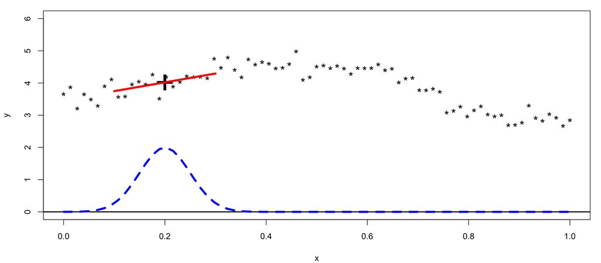

```r
par(mfrow = c(1,1),mar=c(4,4,1,1))
plot(x,y,ylim=c(0,6),cex=1.5,pch="*")
abline(h=0,lwd=2)
points(x1,coef(fit1)[1],pch="+",cex=4)
lines(x,w1,lty="dashed",lwd=4,col="blue")
x_grid1 = seq(0.1,0.3,0.01); y_grid1 = coef(fit1)[[1]] + coef(fit1)[[2]] * (x_grid1-x1)
lines(x_grid1,y_grid1,lwd=4,col="red")
```

- Similarly, to estimate $\mu(0.8)$, we fit the local linear regression model

  $\underset{\betav}{\min} \sum_{n=1}^N \Big[Y_n - \beta_0 - \beta_1(X_n-0.8) \Big]\,K\left(\frac{X_n-0.8}{h}\right)$

  which yields $\mu(0.8)\approx \betah_0 =3.199$

```r
h=0.05  # arbitrarily choosing the bandwidth
x2 = 0.8
scale=.25;w2 = scale*dnorm(x,mean=x2,sd=h)
fit2 = lm(y~I(x-x2),weights=w2) # finding the local linear regression at x=0.8
coef(fit2)
```

**(Intercept)**

3.19809539138174

**I(x - x2)**

-4.79830307819018

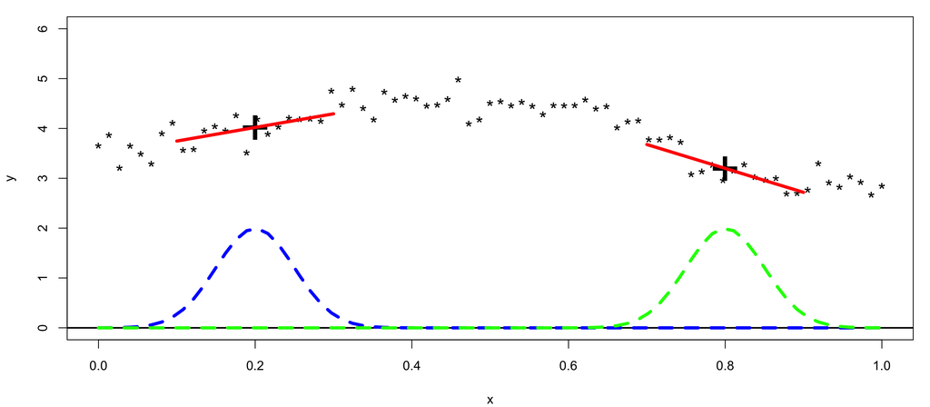

```r
par(mfrow = c(1,1),mar=c(4,4,1,1))
plot(x,y,ylim=c(0,6),cex=1.5,pch="*")
abline(h=0,lwd=2)
points(x1,coef(fit1)[1],pch="+",cex=4)
points(x2,coef(fit2)[1],pch="+",cex=4)
lines(x,w1,lty="dashed",lwd=4,col="blue")
lines(x,w2,lty="dashed",lwd=4,col="green")
x_grid2 = seq(0.7,0.9,0.01); y_grid2 = coef(fit2)[[1]] + coef(fit2)[[2]] * (x_grid2-x2)
lines(x_grid1,y_grid1,lwd=4,col="red")
lines(x_grid2,y_grid2,lwd=4,col="red")
```

- We can use the `locpoly()` function of `KernSmooth` package to fit local polynomial models.

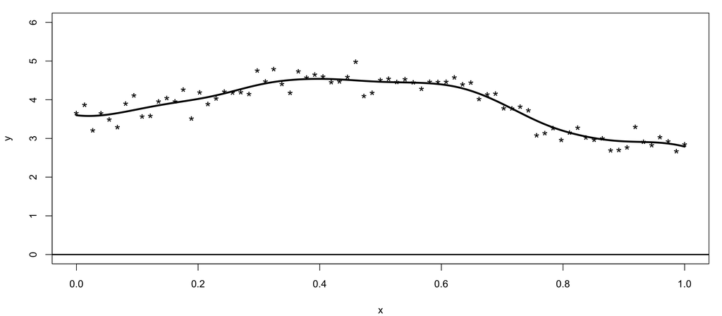

```r
library("KernSmooth")
h=0.05  # arbitrarily choosing the bandwidth
fit_locpoly <- locpoly(x,y, bandwidth = h) # finding the local linear regression on the grid
par(mfrow = c(1,1));par(mar=c(4,4,1,1))
plot(x,y,ylim=c(0,6),cex=1.5,pch="*")
abline(h=0,lwd=2)
lines(fit_locpoly$x,fit_locpoly$y,lwd=3,lty=1)
```

- The parameter $h$ in the kernel weights $K\left(\frac{X_n-x_k}{h}\right)$ represents the bias/variance tradeoff of the estimator for $\mu$:
  - Larger values of $h$ lead to larger kernel weights for observation that are not near $x_k$. Thus, the estimator becomes smooth (low variance) and biased
  - Smaller values of $h$ lead to smaller kernel weights for observation that are not near $x_k$. Thus, the estimator becomes ragged (high variance) and unbiased

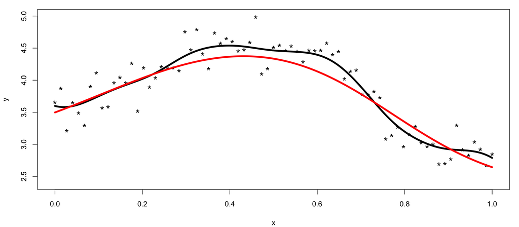

```r
h = 3 * 0.05 # large bandwidth (low variance and high bias)
fit_underfit <- locpoly(x,y, bandwidth = h)
par(mfrow = c(1,1));par(mar=c(4,4,1,1))
plot(x,y,ylim=c(2.4,5),cex=1.5,pch="*")
lines(fit_locpoly$x,fit_locpoly$y,lwd=4)
lines(fit_underfit$x,fit_underfit$y,lwd=4,col="red")
```

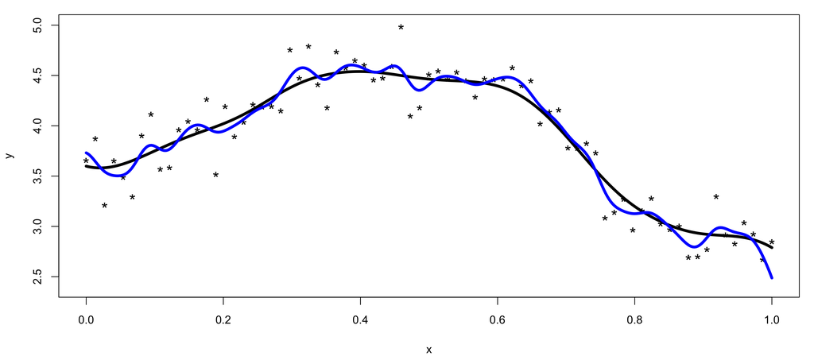

```r
h = 0.05/3 # small bandwidth (high variance and low bias)
fit_overfit <- locpoly(x,y, bandwidth = h)
par(mfrow = c(1,1));par(mar=c(4,4,1,1))
plot(x,y,ylim=c(2.4,5),cex=1.5,pch="*")
lines(fit_locpoly$x,fit_locpoly$y,lwd=4)
lines(fit_overfit$x,fit_overfit$y,lwd=4,col="blue")
```

- One way to identify a good choice of bandwidth $h$ is the **direct plug-in (DPI)** method
- This method find the value of $h$ that minimizes the mean integrated square error (MISE)

\begin{align*} \Eb\left(\int_{\min(X_n)}^{\max(X_n)} (\mu(x) - \muh(x))^2 \dd x\right) \end{align*}

- Here, $\mu(x):= \Eb(Y|X=x)$, and $\muh$ is the estimated $\mu$
- One can use the `dpill()` function in the `KernSmooth` package to find the optimal bandwidth using the DPI method

```r
dpill(x,y)
```

0.0459755185599128

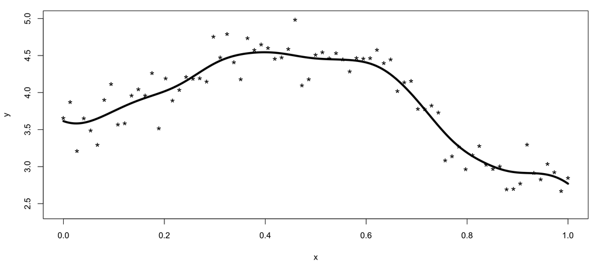

```r
h = dpill(x,y) #finding the optimal bandwidth with dpi
fit_dpi <- locpoly(x,y, bandwidth = h)
par(mfrow = c(1,1));par(mar=c(4,4,1,1))
plot(x,y,ylim=c(2.4,5),cex=1.5,pch="*")
lines(fit_dpi$x,fit_dpi$y,lwd=4)
```

## 1.1. Loess

- **Loess** (locally estimated scatterplot smoothing) and its earlier version **Lowess** (locally weighted scatterplot smoothing) are local polynomial regressions with non-constant bandwidth that is chosen according to a hyperparameter called **span**
- If **span** $<1$, the bandwidth at each estimation point is chosen such that (1-span) portion of observations are assigned zero weights
- If **span** $>1$, then the bandwidth is $span * h(x,1)$, where $h(x,1)$ is the bandwidth for the case $span=1$
- The explanation of how the weights are selected is beyond the scope of this course.
- The R function `loess()` can be used to fit a loess model (we have already used this function in several scatter plots for regression diagnostics)
- `span` is the span hyperparameter and `deg` is the degree of the local polynomial (i.e. $p$)
- Note that there is no need to specify the bandwidth, `loess()` automatically find the best bandwidth

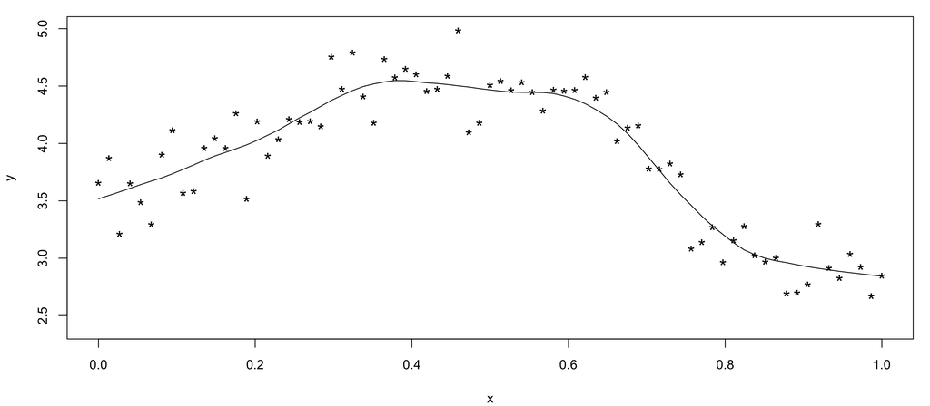

```r
fit_loess <- loess(y~x, span=0.25, deg=1)
par(mfrow = c(1,1));par(mar=c(4,4,1,1))
plot(x,y,ylim=c(2.4,5),cex=1.5,pch="*")
lines(x,predict(fit_loess, x))
```

- Unlike the `localpoly()` function, the `loess()` function can accept multiple regression (several predictors). Let us see an example using the simulated data from the previous lecture.

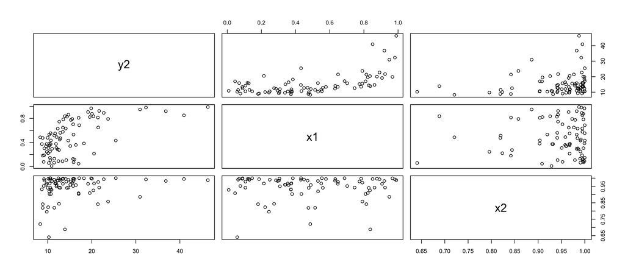

```r
n = 80
set.seed("781235")
e = matrix(runif(12*n),nrow=n) %*% rep(1,12)
e = abs(e)^4
e= e/mean(e)
x1 = runif(n)
x1 = sort(x1)
x2 = rbeta(n,6,.5)
y2 = (8*x2 + x1 + 5*x1^3) + ( 4* x2 + x1 + 7*x1^3) * e
pairs(~y2+x1+x2)
```

- The following R code fits a loess model to the data using both $X_1$ and $X_1$

```r
fit_loess2 <- loess(y2~x1+x2, span=0.75, deg=1)
```

- The residual plot of the loess regression show non-normality and non-constant variance. Does these plots invalidate the fitted model?

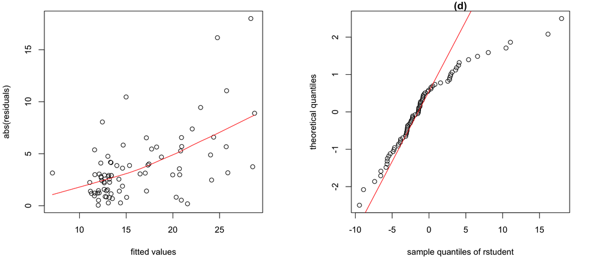

```r
par(mfrow=c(1,2));par(mar=c(5,4,1,4))
plot(fit_loess2$fit,abs(fit_loess2$resid),xlab = "fitted values", ylab = "abs(residuals)")
smoother  = loess(abs(fit_loess2$resid)~ fit_loess2$fit,span=1,deg=1)
ord = order(fit_loess2$fit)
lines(fit_loess2$fit[ord],smoother$fit[ord], col="red")
qqnorm(fit_loess2$resid,datax=T,main="(d)",xlab="theoretical quantiles",ylab="sample quantiles of rstudent")
qqline(fit_loess2$resid,datax=T, col="red")
```

# 2. Penalized spline regression

- Splines are a second popular method for non-parametric regression
- A p-degree polynomial spline is a piecewise polynomial function which has continuous (p-1)-th derivative
- Let $x_1<x_2<\dots<x_m$ be the "knots" of a p-degree spline, that is, the values where the pieces are joint together. The general form of the spline is

\begin{align*} s(x) = \begin{cases} a_{0,0} + a_{0,1}\,x + \dots + a_{0,p}\,x^p;&\quad x<x_1\\ a_{1,0} + a_{1,1}\,x + \dots + a_{1,p}\,x^p;&\quad x_1\le x < x_2\\ \vdots\\ a_{m,0} + a_{m,1}\,x + \dots + a_{m,p}\,x^p;&\quad x_m\le x\\ \end{cases} \end{align*}

- We have $(m+1)(p+1)$ parameters $a_{j,k}$
- To make sure that $s(x)$ have a continuous $(p-1)$-th derivative, we should impose $p$ equations at each knot
- Specifically, we should have, for $k\in\{1,\dots,m\}$:

\begin{align*}\tag{$\star\star$} \begin{cases}\displaystyle s(x_k)=\lim_{x\to x_k^-} s(x)\\ \displaystyle s'(x_k)=\lim_{x\to x_k^-} s'(x)\\ \qquad\vdots\\ s^{(p-1)}(x_k)=\lim_{x\to x_k^-} s^{(p-1)}(x) \end{cases} \end{align*}

- This results in $m\,p$ equations
- By using these equations, we can specify an spline by using $(m+1)(p+1) - mp = m+p+1$ parameters
- To see the last statement more clearly, we can solve $(\star\star)$. It can be shown that the solution is given by

\begin{align*} s(x) = \beta_0 + \beta_1\,x + \dots + \beta_p\,x^{p} + b_1\,(x-x_1)_+^p + \dots + b_m\,(x-x_m)_+^p, \end{align*}

- Here, $\beta_0$,..., $\beta_p$, $b_1$, ..., $b_m$ are $m+p+1$ parameters (that are related to $a_{k,j}$-s) and

\begin{align*} (x)_+^p = \begin{cases} 0;&\quad x\le0\\ x^p;&\quad x>0 \end{cases} \end{align*}

- We can then consider a p-degree spline regression with $m$ knots

\begin{align*} \min \sum (Y_i - s(X_i;\betav))^2 + \lambda\, \betav^\top\,D\,\betav \end{align*}

- Here $s(x;\betav) = \beta_1\,B_1(x) + \dots + \beta_{m+p+1}\,B_{m+p+1}(x)$, where $B_i(x)$ form a spline basis (e.g. $B_0(x)=1,\dots, B_p(x)=x^p, B_{p+1}(x)=(x-x_1)_+^p,\dots, B_{p+m}(x)=(x-x_m)_+^p$)
- The penalty term $\betav^\top\,D\,\betav$ penalizes "wiggly" functions
- A common choice for the penalty function is

\begin{align*} D_{ij} = \int_{\min(X_i)}^{\max(X_i)} B''_i(x)B''_j(x) \dd x \quad \Longrightarrow\quad \lambda\,\betav^\top\,D\betav = \lambda \int_{\min(X_i)}^{\max(X_i)} (s''(x;\betav))^2 \dd x \end{align*}

- The penalty term forces the model to choose fewer parameters
- The cubic smoothing splines are very common spline regression. They have $p=3$ and use the 2-nd derivative penalty term as above

```r
library(mgcv)
cuSpline = gam(y ~ s(x, bs = "cr")) #cubic regression spline
summary(cuSpline)
```

```
Family: gaussian
Link function: identity

Formula:
y ~ s(x, bs = "cr")

Parametric coefficients:
            Estimate Std. Error t value Pr(>|t|)
(Intercept)   3.8734     0.0244   158.7   <2e-16 ***
---
Signif. codes:  0 ‘***’ 0.001 ‘**’ 0.01 ‘*’ 0.05 ‘.’ 0.1 ‘ ’ 1

Approximate significance of smooth terms:
       edf Ref.df     F p-value
s(x) 7.345  8.326 71.68  <2e-16 ***
---
Signif. codes:  0 ‘***’ 0.001 ‘**’ 0.01 ‘*’ 0.05 ‘.’ 0.1 ‘ ’ 1

R-sq.(adj) =  0.889   Deviance explained =   90%
GCV = 0.050245  Scale est. = 0.044654  n = 75
```

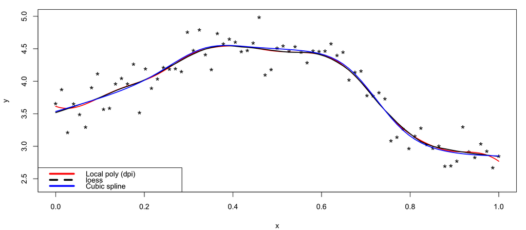

```r
par(mfrow = c(1,1));par(mar=c(4,4,1,1))
plot(x,y,ylim=c(2.4,5),cex=1.5,pch="*")
lines(fit_dpi$x,fit_dpi$y,lwd=2,col="red")
lines(x,predict(fit_loess, x),lwd=2,col="black")
lines(x,fitted(cuSpline),lwd=2,col="blue")
legend("bottomleft",c("Local poly (dpi)","loess","Cubic spline"),
       lty=c(1,2,1),lwd=4,col=c("red", "black", "blue"))
```

- This concludes our discussion of regression models.
- There are other topics which we have not learned about, e.g. regularized regression (ridge, lasso, elastic net), support vector machines, decision trees and random forests, ensemble methods (bagging, boosting), etc
- These topics are covered in CFRM 521

$\newcommand\Fc{\mathscr{F}}$ $\newcommand{\eps}{\varepsilon}$ $\newcommand{\Var}{\operatorname{Var}}$ $\newcommand\Cov{\operatorname{Cov}}$ $\newcommand{\sig}{\sigma}$ $\newcommand{\al}{\alpha}$ $\newcommand{\gam}{\gamma}$ $\newcommand\ph{\varphi}$ $\newcommand\rb{\bar{r}}$ $\newcommand{\Xb}{\bar{X}}$ $\newcommand{\Yb}{\bar{Y}}$ $\newcommand\Eb{\mathbb{E}}$ $\newcommand\Pb{\mathbb{P}}$ $\newcommand\Qb{\mathbb{Q}}$ $\newcommand\Rb{\mathbb{R}}$ $\newcommand\Zb{\mathbb{Z}}$ $\newcommand\Nb{\mathbb{N}}$ $\newcommand\Av{\textbf{A}}$ $\newcommand\Fv{\textbf{F}}$ $\newcommand\Gv{\textbf{G}}$ $\newcommand\Hv{\textbf{H}}$ $\newcommand\Kv{\textbf{K}}$ $\newcommand\Iv{\textbf{I}}$ $\newcommand\Pv{\textbf{P}}$ $\newcommand\Sv{\textbf{S}}$ $\newcommand\Xv{\textbf{X}}$ $\newcommand\Yv{\textbf{Y}}$ $\newcommand\Zv{\textbf{Z}}$ $\newcommand\av{\mathbf{a}}$ $\newcommand\xv{\mathbf{x}}$ $\newcommand\yv{\mathbf{y}}$ $\newcommand\zv{\mathbf{z}}$ $\newcommand\Cv{\mathbf{C}}$ $\newcommand\mv{\mathbf{m}}$ $\newcommand\nv{\mathbf{n}}$ $\newcommand\pv{\mathbf{p}}$ $\newcommand\sv{\mathbf{s}}$ $\newcommand\wv{\mathbf{w}}$ $\newcommand\Wv{\textbf{W}}$ $\newcommand\betav{{\boldsymbol\beta}}$ $\newcommand\etav{{\boldsymbol\eta}}$ $\newcommand\epsv{{\boldsymbol\varepsilon}}$ $\newcommand\delv{{\boldsymbol\delta}}$ $\newcommand\Lamv{{\boldsymbol\Lambda}}$ $\newcommand\lamv{{\boldsymbol\lambda}}$ $\newcommand\muv{{\boldsymbol\mu}}$ $\newcommand\piv{{\boldsymbol\pi}}$ $\newcommand\Pbh{\widehat{\Pb}}$ $\newcommand\phh{\widehat{\varphi}}$ $\newcommand\Ebh{\widehat{\Eb}}$ $\newcommand\Qh{\widehat{Q}}$ $\newcommand\Ih{\widehat{I}}$ $\newcommand\pih{\widehat{\pi}}$ $\newcommand\Pih{\widehat{\Pi}}$ $\newcommand\Wh{\widehat{W}}$ $\newcommand\Fh{\widehat{F}}$ $\newcommand\Yh{\widehat{Y}}$ $\newcommand\Yvh{\widehat{\Yv}}$ $\newcommand\Ah{\widehat{\Ac}}$ $\newcommand\uh{\widehat{u}}$ $\newcommand\vh{\widehat{v}}$ $\newcommand\fh{\widehat{f}}$ $\newcommand\hh{\widehat{h}}$ $\newcommand\Bh{\widehat{B}}$ $\newcommand\rhoh{\widehat{\rho}}$ $\newcommand\nuh{\widehat{\nu}}$ $\newcommand\varphih{\widehat{\varphi}}$ $\newcommand\alh{\widehat{\al}}$ $\newcommand\thetah{\widehat{\theta}}$ $\newcommand\betah{\widehat{\beta}}$ $\newcommand\betavh{\widehat{\boldsymbol\beta}}$ $\newcommand\kaph{\widehat{\kappa}}$ $\newcommand\sigh{\widehat{\sigma}}$ $\newcommand\epsh{\widehat{\eps}}$ $\newcommand\epsvh{\widehat{\epsv}}$ $\newcommand\epst{\widetilde{\eps}}$ $\newcommand\muh{\widehat{\mu}}$ $\newcommand\dd{\mathrm{d}}$ $\newcommand\ee{\mathrm{e}}$

# 3. Weak and strict stationary time series

**Definition:** A stochastic process is an indexed collection of real-valued random variables

\begin{align*} P := \{ P(t): t\in \Rb,\text{ where P(t) is a random variable}\} \end{align*}

- We can also think of a stochastic process as a function-valued random variable $P: \omega \to P(\cdot,\omega)$ that in each random outcome $\omega$ takes the function $P(\cdot, \omega)$
- A **time series** is an observed path of a stochastic process
- Consider the following examples of *"time series"*

'IBM'

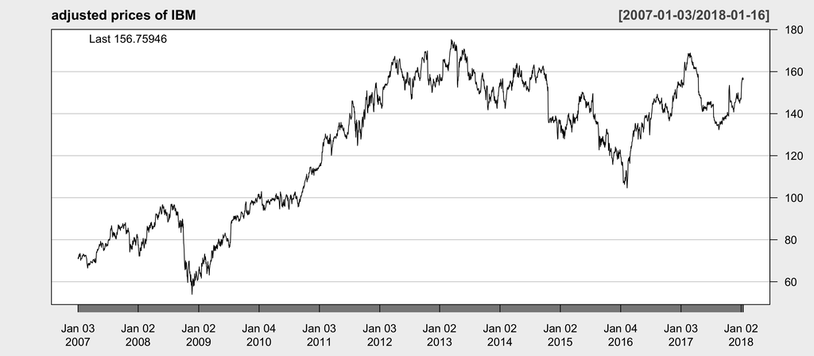

```r
library(quantmod)
getSymbols("IBM", from="2007-01-03", to="2018-1-17", src="yahoo")
chartSeries(IBM$IBM.Adjusted,name = "adjusted prices of IBM",
            theme=chartTheme("white", up.col='black'))
```

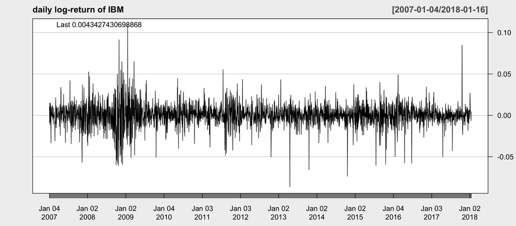

```r
IBMrtn = diff(log(IBM$IBM.Adjusted))[-1] # daily log returns
chartSeries(IBMrtn,
            name = "daily log-return of IBM",
            theme=chartTheme("white", up.col='black'))
```

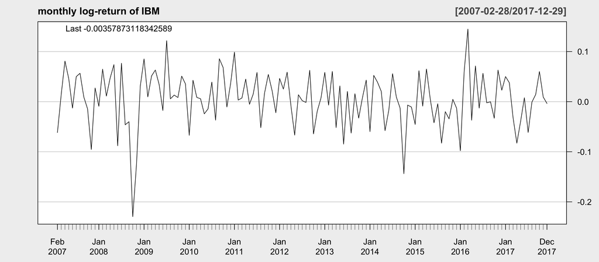

```r
months = endpoints(IBM, on="months")
months = months[-length(months)]
IBMrtn_monthly = diff(log(IBM$IBM.Adjusted[months,]))[-1]# monthly log returns
chartSeries(IBMrtn_monthly,
            name = "monthly log-return of IBM",
            theme=chartTheme("white", up.col='black'))
```

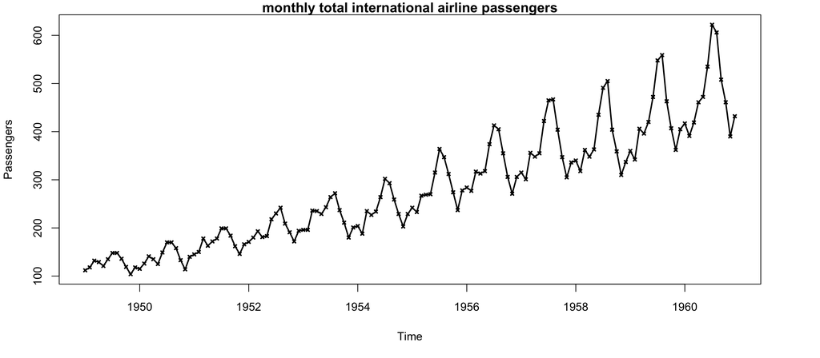

```r
par(mar=c(5,4,1,4))
library(Ecdat)
data(AirPassengers) # monthly total international airline passengers
z = as.ts(AirPassengers, start=1949, frequency=12)
plot(z,type="o",ylab="Passengers",cex=0.5,lwd=2,pch=4,
    main="monthly total international airline passengers")
```

- How should we define the distribution of a stochastic process?
- We say that we know the distribution of a stochastic process, if we are able to specify the joint distribution of $X_{t_1}$, ... , $X_{t_n}$, for any choice of $n$, $t_1$, ... , $t_n$

**Definition:** The finite dimensional distribution of a stochastic process $(X_t)_{t\in\Rb}$ is the family of joint distributions of $X_{t_1}$, $X_{t_2}$, ... , $X_{t_n}$, for any choice of $n$, $t_1$, $t_2$, ... , $t_n$

- Statistical analysis of a random object requires sampling of that object
- A time series is a single observation of an stochastic process
- A sample from an stochastic process is a set of many time series generated by the stochastic process
- For most financial time series, sampling is impossible, since we only have one *"history"*
- However, if the stochastic process is *"stationary"*, then we can break its historical values into part, and treat each part as an observation
- Consider a process $r=\{r_0,r_1, \dots\}$
- $r$ is **"strictly stationary"** if the multivariate random variables $(r_0, r_1, \dots, r_n)$ and $(r_T, r_{T+1}, \dots, r_{T+n})$ have the same distribution for all values of $n$ and $T$
- $r$ is **"weakly stationary"** if all the three conditions below are true:
  - $\Eb(r_t) = \mu$, for all $t$ and some constant $\mu$
  - $\Var(r_t) = \sig^2$, for all $t$ and some constant $\sig^2$
  - $\Cov(r_t, r_{t-h}) = \gam(|h|)$, for all $t$ and some function $\gam(h)$
- For a strictly stationary time series, **distributions** are time-invariant
- For a weakly stationary time series, the first **two moments** are time-invariant
- What is the practical implications of weak stationarity?
  - Past data: time plot of $\{r_t\}$ varies around a fixed level within a finite range
  - Future data: The first two moments of a future $r_t$ are the same as those of the existing data
- Can you guess which of the time series above are (most likely) generated by a stationary stochastic process?
- A deterministic trend (such as an increasing, decreasing, or seasonal trend) is an indication of non-stationarity
- However, changes in mean and variability of a time series can be a result of **"mean-reversion"** or **"variance clustering,"** both of which can be generated by stationary stochastic processes
- Proving (or disproving) stationarity by using a chart can be difficult
- We need statistical tests for detecting stationarity/non-stationarity
- **unit-root tests** are statistical test for checking stationarity. We will discuss them after learning a bit more time series modeling

## 3.1. Mean and variance of weakly stationary processes

- Let $r=\{r_1,\dots, r_n\}$ be a time series of a weakly stationary process. Then, $\mu:=\Eb(r_t)$ is the mean of $r$ and $\sigma^2 = \Var(r_t)$ is its variance
- We can estimate $\mu$ by the sample average $\rb=\frac{\sum_{i=1}^n r_i}{n}$
- To estimate $\sig^2$, we can use the sample variance $\sigh^2 = \frac{\sum_{i=1}^n (r-\rb)^2}{n-1}$
- To test $H_0: \mu=0$ versus $H_1: \mu\ne 0$, we use the test statistic $\displaystyle T=\frac{\rb}{\sqrt{\frac{\sigh^2}{n}}}$
- Under $H_0$ and for large sample size $n$, the distribution of $T$ is approximately standard normal
- Decision rule for significance level of $\al$: Reject $H_0$ if $|T|> Z_{1-\frac{\al}{2}}$, where $Z_{1-\frac{\al}{2}}$ is the $1-\frac{\al}{2}$-quantile of the standard normal distribution

## 3.2. Autocovariance and autocorrelation

- For a weakly stationary process $\{r_t\}$, the *"autocovariance function (ACF)"* is

\begin{align*} \gam(h) = \Cov(r_t, r_{t-h});\quad h\in\Rb \end{align*}

- Note that the right hand side is independent of $t$, since $\{r_t\}$ is weakly stationary
- We have $\gam(-h) = \gam(h)$ and $\gam(0) = \Var(r_t)=\sig^2$. Thus, we only need to specify $\gam(1)$, $\gam(2)$, ...
- For $k\in\{1,2,\dots\}$, $\gam(k)$ is called the lag-$k$ autocovariance
- The autocorrelation function (ACF) is given by

\begin{align*} \rho(h) = \frac{\Cov(r_t, r_{t-h})}{\sqrt{\Var(r_t)\Var(r_{t-h})}} = \frac{\gam(h)}{\gam(0)};\quad h\in\Rb \end{align*}

- We have $\rho(0) = 1$ and $\rho(-k) = \rho(k)$ (why?)
- To estimate autocorrelation, we use the sample autocorrelation function (sample ACF)

\begin{align*} \rhoh(h) = \frac{\sum_{t=1}^{n-h} (r_t-\rb)(r_{t+h}-\rb)}{\sum_{t=1}^n (r_t-\rb)^2} \end{align*}

- To test if autocorrelation is zero, we have two options:
- **Individual test:** to test $H_0$: $\rho(k) = 0$ versus $H_1$: $\rho(k)\ne 0$, use the statistic

  $T = \frac{\rhoh(k)}{\sqrt{\frac{1}{n}}} = \sqrt{n} \rhoh(k)$

  Under $H_0$ and for large sample size $n$, T is standard normal. Thus, at the significance level of $\al$, reject $H_0$ if $|T|>Z_{1-\frac{\al}{2}}$, where $Z_{1-\frac{\al}{2}}$ is the $(1-\frac{\al}{2})$-quantile of the standard normal distribution.
- **Joint test (Ljung-Box):** to test $H_0$: $\rho(1) = \rho(2) = \dots = \rho(m) = 0$ versus $H_1$: $\rho(k)\ne 0$ for a $k\in\{1,\dots,m\}$, use the Ljung-Box test statistic

  $Q(m) = n(n+2)\sum_{h=1}^m \frac{\rhoh^2(h)}{n-h}$

  Under $H_0$ and for large sample size $n$, $Q(m)$ has chi-squared distribution with m degree of freedom. Thus, at the significance level of $\al$, reject $H_0$ if $Q(m)>\chi^2_m(1-\al)$, where $\chi^2_m(1-\al)$ is the $(1-\al)$-quantile of a chi-squared distribution with $m$ degree of freedom
- Let us check if the daily returns of the IBM are uncorrelated
- Let us assume, for now, that we have established that daily returns are stationary
- So, it make sense to find their ACF. The R function `acf()` provides the sample ACF plot
- The sample ACF indicate some significant autocorrelation at lags 4, 5, and 10

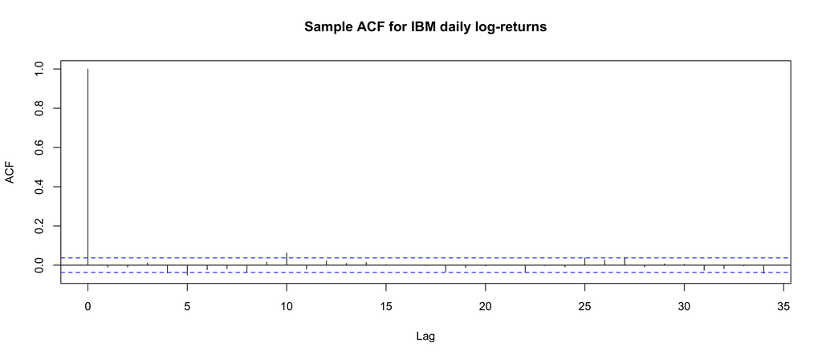

```r
acf(IBMrtn, main="Sample ACF for IBM daily log-returns")
```

- To confirm autocorrelation in returns, we can use the Ljung-Box test, which can be conducted using the R function `Box.test()`
- According to Ljung-Box test, there are non-zero autocorrelation in the first 5 and 10 lags

```r
Box.test(IBMrtn, lag = 5, type = "Ljung-Box") # Ljung-Box Q(5)
Box.test(IBMrtn, lag = 10, type = "Ljung-Box") # Ljung-Box Q(10)
```

```
	Box-Ljung test

data:  IBMrtn
X-squared = 12.585, df = 5, p-value = 0.0276
```

```
	Box-Ljung test

data:  IBMrtn
X-squared = 29.945, df = 10, p-value = 0.0008745
```